# Fake It Till You Make It

Simulating Data to Learn About ML

Bob Horton

10/13/2020

```r
library(dplyr)
library(randomForest)
library(glmnet)
library(ROCR)
library(ggplot2)

set.seed(params$random_seed)
options(width=120)
```

## Targeting the Edges of the ROC Curve

Different learning algorithms can learn different signals from a dataset. Here I put different signals in a simulataed dataset so that a linear model (`glmnet`) will have better performance on one edge of the ROC curve, and a tree-based (`randomForest`) model will have better performance on the other edge.

```r
simulate_data <- function(num_rows=1000, num_categorical=5, cardinality=3, num_numeric=10,
                          noise=0, y_threshold_quantile=0.95, y_fun=NULL, ...){

  simdata <- data.frame(id=1:num_rows)

  for (i in 1:num_categorical){
    col_name <- sprintf("cat%02d", i)
    simdata[[col_name]] <- sample(LETTERS[1:cardinality], num_rows, replace=TRUE)
  }

  for (i in 1:num_numeric){
    col_name <- sprintf("num%02d", i)
    simdata[[col_name]] <- rnorm(num_rows)
  }

  if (!is.null(y_fun)){
    simdata[['y']] <- y_fun(simdata, ...) + rnorm(num_rows, sd=noise)
    simdata[['y_cat']] <- simdata[['y']] > quantile(simdata[['y']], probs=y_threshold_quantile)
  }

  simdata
}
```

```r
y_edges <- function(df, numeric_term_weight, interaction_weight){
  with(df, {
    numeric_term_weight*(0.6*num01 + 0.7*num02 + 0.8*num03 + 0.9*num04 + 1.0*num05 +
                         1.1*num06 + 1.2*num07 + 1.3*num08 + 1.4*num09 + 1.5*num10) +
      interaction_weight * ifelse(cat01 == cat02, 1, -1)
  })
}
```

```r
randomForest_vs_glmnet <- function(df_train, df_test, label, predictors){

  form <- formula(paste(label, paste(predictors, collapse=' + '), sep=' ~ '))

  X_train <- model.matrix(form, df_train)
  y_train <- as.numeric(df_train[[label]])

  X_test <- model.matrix(form, df_test)
  y_test <- as.numeric(df_test[[label]])

  fit_rf <- randomForest(X_train, factor(y_train), ntree=101)
  pred_rf <- predict(fit_rf, X_test, type='prob')[,2]
  rf_pred_obj <- prediction(pred_rf, y_test)

  fit_glmnet <- cv.glmnet(X_train, y_train,  nfolds=5)
  pred_glmnet <- predict(fit_glmnet, newx=X_test)[,1]
  glmnet_pred_obj <- prediction(pred_glmnet, y_test)

  plot(performance(rf_pred_obj, 'tpr', 'fpr'), col='blue', lwd=1.5)
  plot(performance(glmnet_pred_obj, 'tpr', 'fpr'), col='red', lwd=1.5, add=TRUE)

  rf_auc <- performance(rf_pred_obj,'auc')@y.values[[1]]
  glmnet_auc <- performance(glmnet_pred_obj,'auc')@y.values[[1]]

  legend_txt <- c(sprintf('%0.3f randomForest', rf_auc),  sprintf('%0.3f glmnet', glmnet_auc))
  legend('bottomright', legend=legend_txt, text.col=c('blue', 'red'), title='AUC', title.col='black', bty='n')

}
```

Here the `randomForest` model is better on the left edge, and the `glmnet` model is better on the top edge.

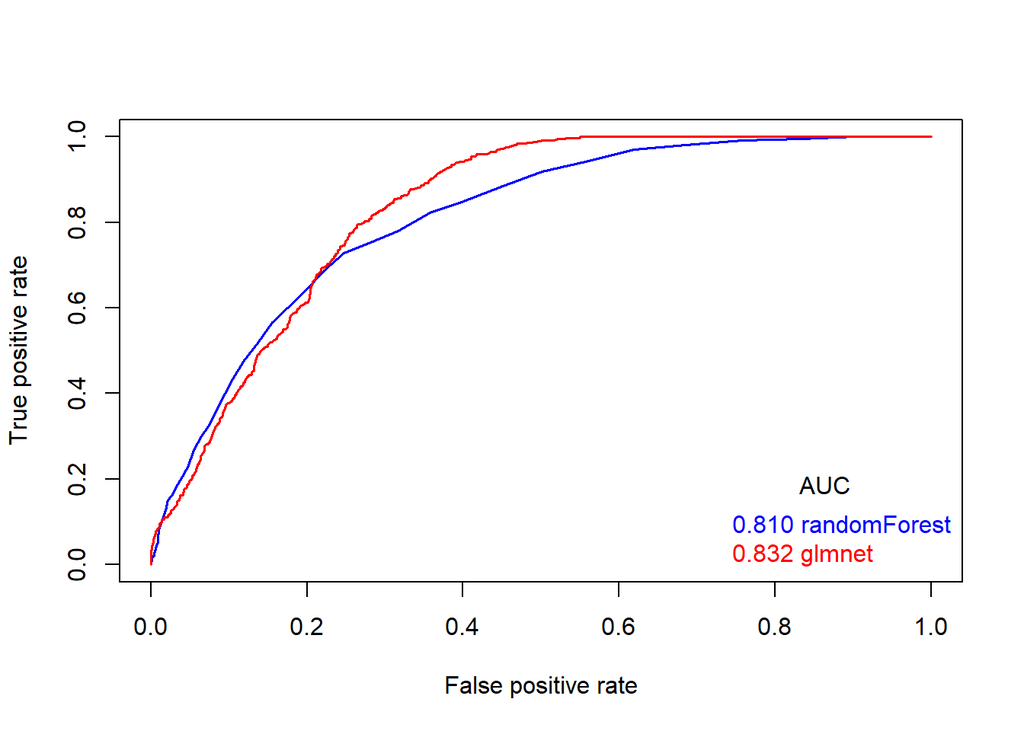

```r
sim_data_params <- list(num_rows=5000, num_categorical=5, cardinality=4, num_numeric=15,
                        noise=2,
                        y_threshold_quantile=0.9,
                        y_fun=y_edges, numeric_term_weight=4, interaction_weight=15)


df_train <- do.call(simulate_data, sim_data_params)
df_test <- do.call(simulate_data, sim_data_params)

label='y_cat'
predictors=setdiff(names(df_train), c('id', 'y', 'y_cat'))

randomForest_vs_glmnet( df_train, df_test, label, predictors)
```

Here the `glmnet` model is better on the left edge, and `randomForest` is better on the top edge.

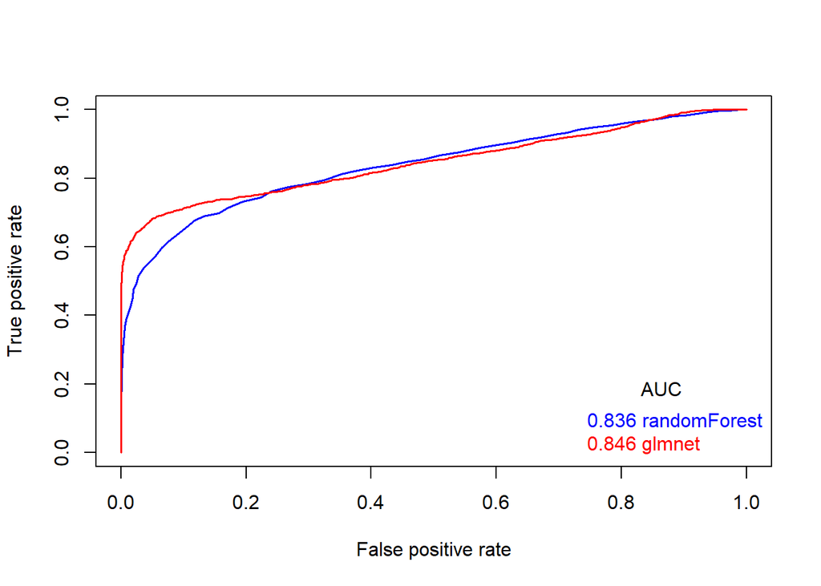

```r
sim_data_params$y_threshold_quantile=0.5

df_train <- do.call(simulate_data, sim_data_params)
df_test <- do.call(simulate_data, sim_data_params)

randomForest_vs_glmnet( df_train, df_test, label, predictors)
```

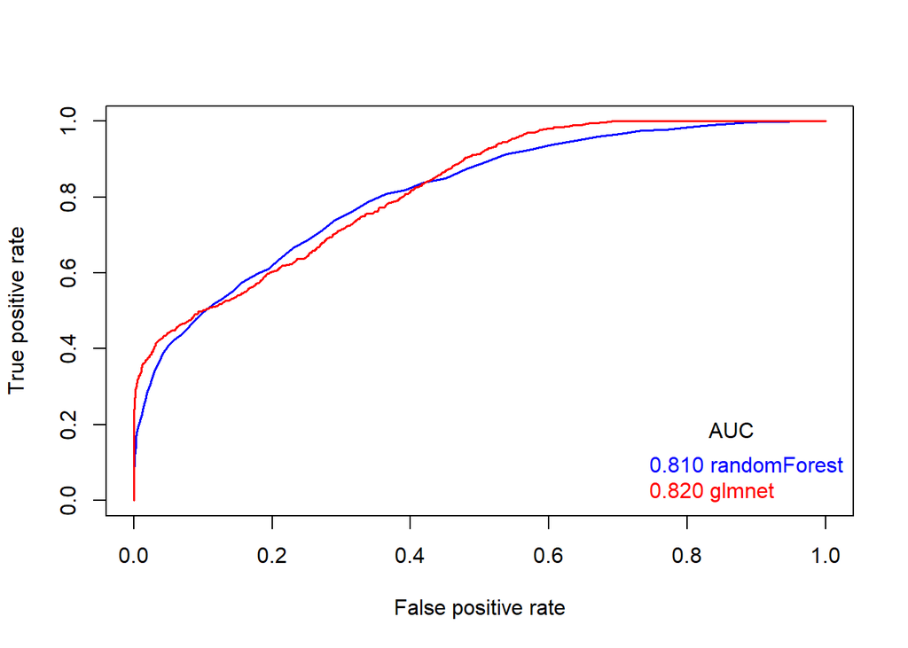

```r
sim_data_params$interaction_weight=12
sim_data_params$y_threshold_quantile=0.75

df_train <- do.call(simulate_data, sim_data_params)
df_test <- do.call(simulate_data, sim_data_params)
randomForest_vs_glmnet( df_train, df_test, label, predictors)
```

## Recursive Feature Elimination

The `caret` package offers several options for estimating feature importance and selecting subsets of features to use as predictors. Here we’ll try using Recursive Feature Selection with randomForest models.

Because [caret doesn’t work if your binary response is of type *logical*](https://stackoverflow.com/questions/27303051/r-estimating-model-variance), we need to cas the outcome variable as a factor.

```r
library(randomForest)

df_train <- do.call(simulate_data, sim_data_params) %>%
  mutate(y_cat=factor(y_cat, levels=c(TRUE, FALSE), labels=c("yes", "no")))

exclude <- c('id', 'y', 'y_cat')
feature_cols <- setdiff(names(df_train), exclude)

label <- 'y_cat'
form <- formula(paste(label, paste(feature_cols, collapse = ' + '), sep=' ~ '))

fit_rf <- randomForest(form, df_train, importance=TRUE)

importance(fit_rf)
```

```
##              yes         no MeanDecreaseAccuracy MeanDecreaseGini
## cat01 10.7907965  8.7513777          12.28180786         31.94360
## cat02 11.1024157  6.0314305          10.87604947         32.44247
## cat03  1.2953964 -0.1075709           0.62070068         25.71037
## cat04 -0.4401007  0.2681725          -0.03936764         26.62227
## cat05  0.2402754 -0.4454937          -0.26942138         26.61168
## num01  5.0323583  2.5205200           5.08849042         97.05704
## num02  8.6852216  5.9488885           9.80135554        103.52408
## num03 14.5392886  8.1844464          13.79164381        114.38828
## num04 17.2707539 10.4311303          17.57096072        124.07663
## num05 13.0887432  6.7935127          12.86817883        114.34293
## num06 17.0010041 12.1644789          19.62507897        132.92913
## num07 17.5635868 13.0493587          20.81506601        130.12898
## num08 25.6890967 17.3977174          28.23986136        155.82604
## num09 26.8802000 17.6893799          29.38066099        161.51280
## num10 37.3944512 25.3709915          40.92681250        182.20269
## num11 -0.3118902  0.3666508           0.12009231         81.61424
## num12 -0.7472782 -1.3860854          -1.55020224         79.76166
## num13 -1.5927297  1.2879472           0.18537925         82.53662
## num14  0.9829830  0.5424732           1.00512397         84.60361
## num15  0.1393670  0.8938711           0.84168897         84.85642
```

Here I use only 3 cross-validation folds; normally you would use more (the default is 10), but that takes longer.

```r
library(caret)
control <- rfeControl(functions=rfFuncs, method="cv", number=3)

x=df_train[,predictors]
y=df_train[[label]]
results <- rfe(x,y, sizes=c(1:15), rfeControl=control)

print(results)
```

```
##
## Recursive feature selection
##
## Outer resampling method: Cross-Validated (3 fold)
##
## Resampling performance over subset size:
##
##  Variables Accuracy   Kappa AccuracySD KappaSD Selected
##          1   0.6484 0.07068   0.021362 0.04375
##          2   0.7276 0.14925   0.010507 0.03101
##          3   0.7550 0.21178   0.007022 0.02873
##          4   0.7672 0.26166   0.004200 0.02263
##          5   0.7770 0.29077   0.001820 0.01578
##          6   0.7864 0.31561   0.001265 0.01488
##          7   0.7872 0.31285   0.001424 0.01509
##          8   0.7938 0.32674   0.007574 0.03591
##          9   0.7972 0.34258   0.005782 0.02681
##         10   0.8032 0.35261   0.008519 0.03819
##         11   0.8042 0.35474   0.008523 0.04039
##         12   0.8080 0.35978   0.003658 0.02069        *
##         13   0.8072 0.34798   0.001887 0.01843
##         14   0.8048 0.33925   0.005226 0.03083
##         15   0.8054 0.33476   0.005408 0.03082
##         20   0.8054 0.32718   0.005591 0.03625
##
## The top 5 variables (out of 12):
##    num10, num09, num08, num07, num06
```

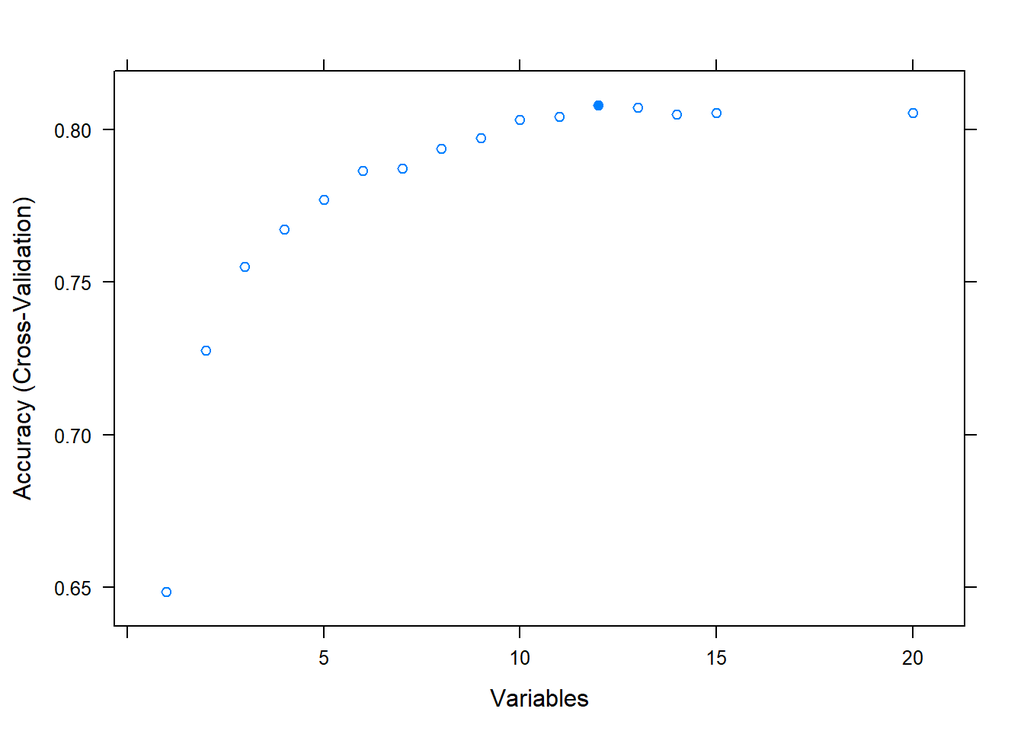

```r
plot(results)
```

```r
predictors(results)
```

```
##  [1] "num10" "num09" "num08" "num07" "num06" "num04" "num03" "cat01" "num05" "cat02" "num02" "num01"
```

### Repeated numerical columns

```r
repeat_column <- function(df, col, num_reps, suffix='rep'){
  for (i in 1:num_reps){
    new_col_name <- sprintf("%s_%s_%02d", col, suffix, i)
    df[[new_col_name]] <- df[[col]]
  }
  df
}

df_train_rep_num01 <- repeat_column(df_train, 'num01', 10)

feature_cols_rep_num01 <- setdiff(names(df_train_rep_num01), exclude)
form <- formula(paste(label, paste(feature_cols_rep_num01, collapse = ' + '), sep=' ~ '))


fit_rf_rep_num01 <- randomForest(form, df_train_rep_num01, importance=TRUE)

importance(fit_rf_rep_num01)
```

```
##                      yes         no MeanDecreaseAccuracy MeanDecreaseGini
## cat01          8.3640401  5.2577656            8.2061210         25.83765
## cat02          8.7406123  6.4870902            9.2093262         25.84707
## cat03          0.1722052 -0.8226284           -0.5904897         21.30535
## cat04         -1.5761656 -0.9510793           -1.6981517         21.75979
## cat05          2.2704308  0.3335280            1.5429074         21.84267
## num01        -12.0469333 19.1932914           18.9242379         33.91498
## num02          7.2545180  5.7626488            8.6643611         88.77464
## num03         10.0004444  7.1100784           11.1868804         96.56723
## num04         11.7576486  8.6745692           13.8639155        104.87899
## num05         13.8077921  8.5429100           14.5689630         98.18442
## num06         15.4183976 11.1766533           17.4951352        112.36813
## num07         16.1200710 12.5613641           18.7720577        114.84292
## num08         24.5433126 17.9337787           28.2542135        134.46377
## num09         24.8187575 18.0575558           30.2612551        140.69332
## num10         34.3915139 20.7728136           35.0509483        162.79523
## num11         -2.4174125 -0.3245119           -1.7711303         67.74213
## num12         -0.3648978 -2.8013800           -2.4819813         65.48067
## num13         -0.7646752 -0.6422095           -0.9751755         67.61487
## num14          0.0480621  1.2962511            1.1961559         68.73712
## num15          0.4387829 -0.5182808           -0.2018382         69.02469
## num01_rep_01 -11.8408270 19.0561332           18.6233801         33.45971
## num01_rep_02 -13.4835845 21.5507402           20.6936251         32.64028
## num01_rep_03 -13.6811426 20.1695703           19.3093007         33.66407
## num01_rep_04 -15.6513392 23.1752634           21.2612429         33.08404
## num01_rep_05 -13.3884503 20.6637977           20.0262552         33.27012
## num01_rep_06 -13.8510046 20.4363894           19.3569031         32.76074
## num01_rep_07 -14.9639978 22.3032986           21.0761980         33.75720
## num01_rep_08 -12.4384448 21.2800361           20.5778073         33.03815
## num01_rep_09 -11.8867014 18.9789106           18.3866363         33.25767
## num01_rep_10 -13.4197391 19.7883241           19.0452866         32.97254
```

```r
x=df_train_rep_num01[, feature_cols_rep_num01]
y=df_train_rep_num01[[label]]
results <- rfe(x,y, sizes=c(1:15), rfeControl=control)

print(results)
```

```
##
## Recursive feature selection
##
## Outer resampling method: Cross-Validated (3 fold)
##
## Resampling performance over subset size:
##
##  Variables Accuracy   Kappa AccuracySD  KappaSD Selected
##          1   0.6396 0.04513   0.009903 0.019800
##          2   0.7260 0.15116   0.002473 0.009808
##          3   0.7606 0.22746   0.006723 0.020698
##          4   0.7756 0.28848   0.002735 0.005466
##          5   0.7808 0.30277   0.005077 0.016550
##          6   0.7834 0.30523   0.008654 0.019653
##          7   0.7888 0.31747   0.006076 0.012106
##          8   0.7962 0.33624   0.006812 0.026692
##          9   0.7996 0.35550   0.001109 0.012650
##         10   0.8054 0.36542   0.002298 0.012334
##         11   0.8078 0.36756   0.001771 0.003898
##         12   0.8090 0.36855   0.003557 0.014220
##         13   0.8094 0.36611   0.003947 0.015189
##         14   0.8098 0.35983   0.004863 0.014299        *
##         15   0.8086 0.35620   0.005687 0.019280
##         30   0.7954 0.27726   0.001801 0.006236
##
## The top 5 variables (out of 14):
##    num10, num08, num09, num07, num06
```

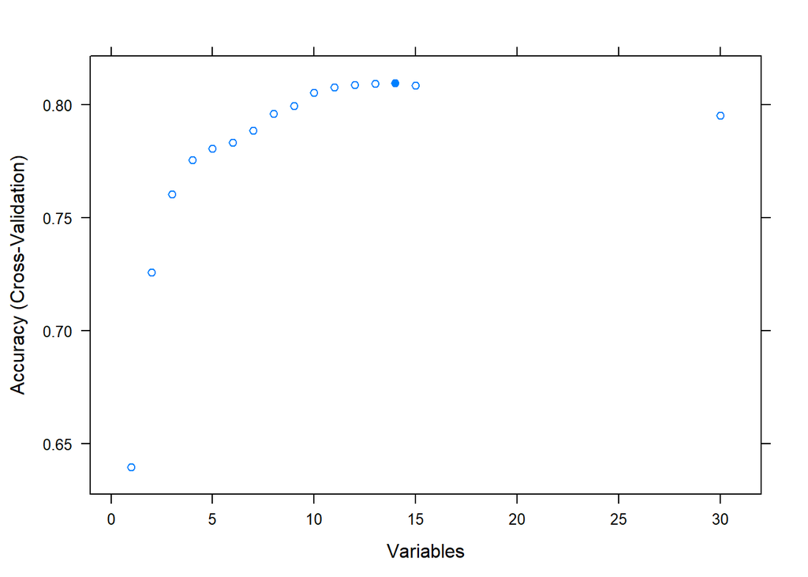

```r
plot(results)
```

```r
predictors(results)
```

```
##  [1] "num10"        "num08"        "num09"        "num07"        "num06"
##  [6] "num04"        "num03"        "num05"        "cat01"        "cat02"
## [11] "num02"        "num01_rep_07" "num01_rep_09" "num01_rep_02"
```

Repeat the most important numerical column:

```r
df_train_rep_num10 <- repeat_column(df_train, 'num10', 10)

feature_cols_rep_num10 <- setdiff(names(df_train_rep_num10), exclude)
form <- formula(paste(label, paste(feature_cols_rep_num10, collapse = ' + '), sep=' ~ '))


fit_rf_rep_num10 <- randomForest(form, df_train_rep_num10, importance=TRUE)

importance(fit_rf_rep_num10)
```

```
##                       yes         no MeanDecreaseAccuracy MeanDecreaseGini
## cat01          8.67744692  5.9559247            9.1573866         24.84435
## cat02          8.17663778  6.8677712            9.8810753         24.98071
## cat03         -0.35790887  0.8551146            0.5198700         20.74354
## cat04          0.47612604 -0.4453246           -0.1032010         20.59926
## cat05         -0.09576833  1.6952548            1.3315134         21.44501
## num01          5.40476436  3.7468385            5.8657614         77.40097
## num02         10.99686218  4.3309845            9.0804677         88.16109
## num03         11.48266469  6.5860377           11.5052946         95.30931
## num04         15.51348086  9.8117774           16.7729462        104.60078
## num05         12.02001868  7.7651428           12.7815516         96.64037
## num06         14.79737325 12.0486857           17.3340977        116.20489
## num07         19.12342448 13.0358282           21.0759389        113.53848
## num08         29.28767717 17.9411142           29.9113770        135.68334
## num09         26.79934264 17.6664791           28.8352710        141.27624
## num10         -8.38576291 21.0601987           21.6751856         41.35744
## num11          0.72367015 -1.2287788           -0.5738716         64.91465
## num12          0.34014947 -1.6432388           -1.1752979         65.32634
## num13         -0.44092185  2.1685146            1.4840503         66.61848
## num14          1.22678033  0.5405963            1.1195497         70.68890
## num15         -0.17101097  0.9547824            0.7572125         67.33406
## num10_rep_01 -11.84683533 19.3553972           18.8394627         43.42171
## num10_rep_02  -8.53067672 20.3830300           20.4844102         42.20287
## num10_rep_03  -8.77401802 19.5431424           19.5119269         41.95009
## num10_rep_04  -8.90360525 18.6742979           18.7733962         39.47458
## num10_rep_05  -9.78857722 19.1371465           19.1043152         44.02290
## num10_rep_06  -8.35592397 20.0488612           20.2808738         40.72795
## num10_rep_07  -7.92846455 19.7241985           19.7973913         42.19411
## num10_rep_08  -9.14861720 19.7403208           19.7973137         40.57195
## num10_rep_09  -8.88538944 22.2594494           22.2404623         41.30499
## num10_rep_10  -9.79099398 20.1111223           20.0070626         40.99215
```

```r
x=df_train_rep_num10[, feature_cols_rep_num10]
y=df_train_rep_num10[[label]]
results <- rfe(x,y, sizes=c(1:15), rfeControl=control)

print(results)
```

```
##
## Recursive feature selection
##
## Outer resampling method: Cross-Validated (3 fold)
##
## Resampling performance over subset size:
##
##  Variables Accuracy   Kappa AccuracySD  KappaSD Selected
##          1   0.6526 0.05421  0.0070383 0.015677
##          2   0.7212 0.12977  0.0025152 0.012848
##          3   0.7426 0.15371  0.0109595 0.047425
##          4   0.7464 0.17757  0.0045095 0.010305
##          5   0.7586 0.21061  0.0024378 0.017280
##          6   0.7712 0.24291  0.0008582 0.024940
##          7   0.7706 0.23754  0.0051822 0.008237
##          8   0.7842 0.28320  0.0118240 0.039469
##          9   0.7944 0.33350  0.0142991 0.051200
##         10   0.7924 0.32412  0.0115058 0.039613
##         11   0.8010 0.35452  0.0063052 0.020676        *
##         12   0.7990 0.34258  0.0088930 0.025872
##         13   0.7968 0.33551  0.0092339 0.030415
##         14   0.7984 0.33607  0.0088927 0.025328
##         15   0.7972 0.32977  0.0072105 0.025766
##         30   0.7934 0.29608  0.0035521 0.012731
##
## The top 5 variables (out of 11):
##    num08, num09, num06, num07, num04
```

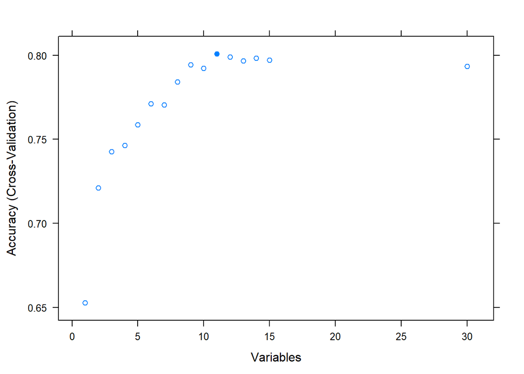

```r
plot(results)
```

```r
predictors(results)
```

```
##  [1] "num08"        "num09"        "num06"        "num07"        "num04"
##  [6] "num03"        "num05"        "num02"        "cat02"        "num10_rep_09"
## [11] "num10"
```

### Repeated categorical column

Repeat one of the interaction columns.

```r
df_train_rep_cat01 <- repeat_column(df_train, 'cat01', 10)

feature_cols_rep_cat01 <- setdiff(names(df_train_rep_cat01), exclude)
form <- formula(paste(label, paste(feature_cols_rep_cat01, collapse = ' + '), sep=' ~ '))


fit_rf_rep_cat01 <- randomForest(form, df_train_rep_cat01, importance=TRUE)

importance(fit_rf_rep_cat01)
```

```
##                       yes         no MeanDecreaseAccuracy MeanDecreaseGini
## cat01         4.880183311  5.7279797            7.1886232         10.92622
## cat02        23.434918790 19.0291569           23.4840250         53.12655
## cat03        -0.895620418 -1.1147206           -1.4464458         26.25034
## cat04         0.949718569  1.0911787            1.4075150         25.51910
## cat05         0.065842969  1.2262001            1.0699765         26.68388
## num01         3.778450370  1.4298926            3.3727866         89.34010
## num02         7.634478443  4.2678936            7.7374310         98.16468
## num03        13.572954624  7.3719125           13.3754089        106.84238
## num04        15.997633331  8.0358086           15.2455013        115.95479
## num05        12.823174997  7.8212377           13.0177533        107.61319
## num06        17.278616012 10.9363109           18.7369470        122.63375
## num07        17.388653266 12.6187682           19.2738013        125.17121
## num08        25.059849549 17.1027240           26.6467347        144.79934
## num09        24.661011878 18.0997972           28.7777004        149.01256
## num10        31.975668433 23.7839947           36.2581072        173.67548
## num11        -0.763927690 -0.1898964           -0.6095698         76.56697
## num12        -0.001978046 -2.1850690           -1.7285053         76.08509
## num13         1.547526372  1.4191277            2.0393569         77.90675
## num14         1.097555800  0.7382108            1.2480297         80.68901
## num15         0.124531600  1.2225171            1.1345640         79.70155
## cat01_rep_01  6.557869061  4.6195801            6.8779550         10.58080
## cat01_rep_02  6.452915543  5.3659861            7.0361709         10.73987
## cat01_rep_03  6.881440651  5.2073984            7.2460726         10.75694
## cat01_rep_04  4.628594967  4.5059020            5.1369331         10.23578
## cat01_rep_05  5.358521972  4.3539505            5.7010286         10.58098
## cat01_rep_06  6.092141684  5.0437046            6.5488785         10.48660
## cat01_rep_07  5.962813155  3.8743489            5.7986548         10.74979
## cat01_rep_08  5.671806507  5.3815277            6.6100745         11.23222
## cat01_rep_09  5.797821542  5.3286930            6.4108734         10.25259
## cat01_rep_10  6.151419776  5.5209684            6.9507537         11.24492
```

```r
x=df_train_rep_cat01[, feature_cols_rep_cat01]
y=df_train_rep_cat01[[label]]
results <- rfe(x,y, sizes=c(1:15), rfeControl=control)

print(results)
```

```
##
## Recursive feature selection
##
## Outer resampling method: Cross-Validated (3 fold)
##
## Resampling performance over subset size:
##
##  Variables Accuracy   Kappa AccuracySD  KappaSD Selected
##          1   0.6408 0.04576  0.0076093 0.009684
##          2   0.7354 0.10064  0.0143151 0.079606
##          3   0.7528 0.11446  0.0068433 0.071063
##          4   0.7538 0.20402  0.0066128 0.020372
##          5   0.7688 0.25009  0.0061753 0.028844
##          6   0.7750 0.26519  0.0087097 0.035043
##          7   0.7892 0.31586  0.0008626 0.012294
##          8   0.7942 0.32321  0.0058310 0.032816
##          9   0.8010 0.35473  0.0029034 0.019550
##         10   0.8038 0.35912  0.0058545 0.029264
##         11   0.8088 0.36999  0.0024584 0.018196
##         12   0.8138 0.38003  0.0049256 0.026876
##         13   0.8122 0.37101  0.0026805 0.020825
##         14   0.8112 0.36369  0.0033599 0.020096
##         15   0.8150 0.37177  0.0059207 0.032939        *
##         30   0.8006 0.29253  0.0064526 0.027425
##
## The top 5 variables (out of 15):
##    num10, cat02, num09, num08, num07
```

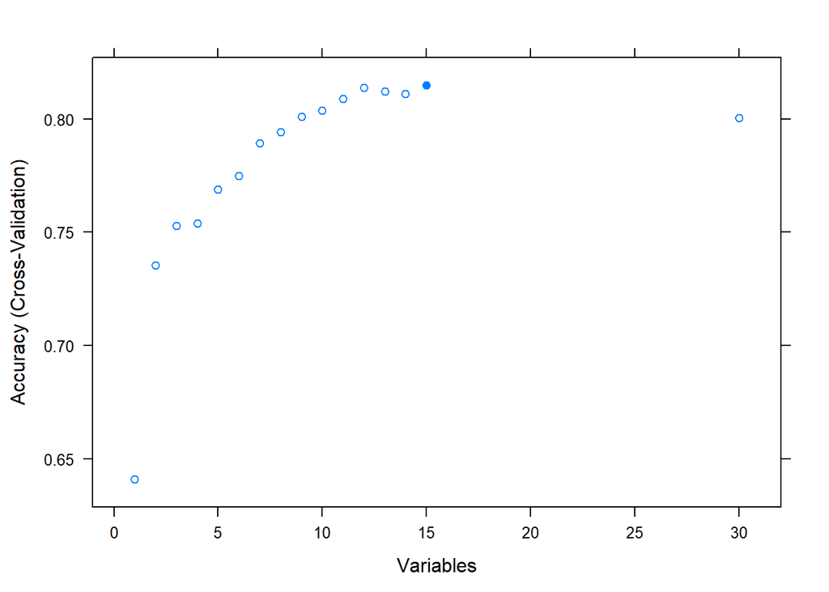

```r
plot(results)
```

```r
predictors(results)
```

```
##  [1] "num10"        "cat02"        "num09"        "num08"        "num07"
##  [6] "num06"        "num04"        "num03"        "num05"        "num02"
## [11] "cat01_rep_06" "cat01_rep_01" "cat01"        "cat01_rep_05" "cat01_rep_09"
```